# Chapter 15 — Charts for Numerical Data

←Back to the bookChapter 15 · Charts for Numerical Data

Part III · Visualizing Data | Chapter 15

Charts for Numerical Data 🐍 Notebook

Five demos on the four workhorse charts for continuous data: the histogram and its bin trap, what a box plot quietly hides, decluttering a line chart, reading a scatter, and the quartet that proves you must always plot your data.

Author: **John Fisher** · Statistics, Data Science and AI: A Visual Handbook · 2026

### 🎯 What you'll build in this notebook

| # | Demo | Idea it builds |
| --- | --- | --- |
| 1 | The bin trap | bin width changes a histogram's apparent shape |
| 2 | What the box hides | box plots compare groups but conceal modality |
| 3 | Taming spaghetti | highlight one line, gray the rest |
| 4 | Reading a scatter | direction, form, strength, and overplotting |
| 5 | Anscombe's quartet | identical stats, four different realities |

## ⚙️ Setup, imports & the book's plotting style

```python
import numpy as np
import pandas as pd
import matplotlib.pyplot as plt
from scipy.stats import gaussian_kde

rng = np.random.default_rng(15)

NAVY="#0a1230"; INK="#1a2138"; INK_SOFT="#4a5578"
CYAN="#0891b2"; PURPLE="#7c3aed"; AMBER="#d97706"; GREEN="#059669"; PINK="#db2777"; BLUE="#2563eb"; GRID="#e6e9f2"
plt.rcParams.update({
    "figure.facecolor":"white","axes.facecolor":"white","figure.dpi":110,"font.size":11,
    "axes.edgecolor":GRID,"axes.linewidth":1.2,"axes.grid":True,"grid.color":GRID,"axes.axisbelow":True,
    "axes.spines.top":False,"axes.spines.right":False,"axes.titlesize":12.5,"axes.titleweight":"bold","axes.titlecolor":INK,
    "axes.labelcolor":INK_SOFT,"axes.labelsize":11,"xtick.color":INK_SOFT,"ytick.color":INK_SOFT,"legend.frameon":False,
})
print("✅ Environment ready.")
```

```
✅ Environment ready.
```

DEMO 1 · THE BIN TRAP

📊 A histogram's shape is a choice

The histogram shows the shape of one variable, but the bin width is editorial. Too few bins oversmooths and hides structure; too many is pure noise. Never trust a single binning, and let a rule like Freedman-Diaconis pick a principled default.

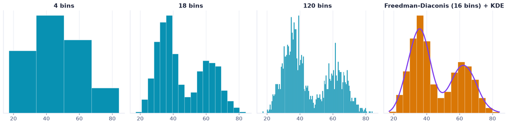

```
4 bins call it one hump; 120 bins is static. The principled binning reveals the truth: two modes.
```

```python
data = np.concatenate([rng.normal(35, 6, 1200), rng.normal(62, 7, 800)])  # secretly bimodal

fig, axes = plt.subplots(1, 4, figsize=(15, 3.8))
for ax, b in zip(axes[:3], [4, 18, 120]):
    ax.hist(data, bins=b, color=CYAN, edgecolor="white", linewidth=0.3)
    ax.set_title(f"{b} bins"); ax.set_yticks([])

# Freedman-Diaconis principled default, with a KDE overlay (density scale)
iqr = np.subtract(*np.percentile(data, [75, 25]))
fd_w = 2 * iqr / len(data) ** (1/3)
fd_bins = int((data.max() - data.min()) / fd_w)
axes[3].hist(data, bins=fd_bins, density=True, color=AMBER, edgecolor="white", linewidth=0.3)
xs = np.linspace(data.min(), data.max(), 300)
axes[3].plot(xs, gaussian_kde(data)(xs), color=PURPLE, lw=2.2)
axes[3].set_title(f"Freedman-Diaconis ({fd_bins} bins) + KDE"); axes[3].set_yticks([])
plt.tight_layout(); plt.show()
print("4 bins call it one hump; 120 bins is static. The principled binning reveals the truth: two modes.")
```

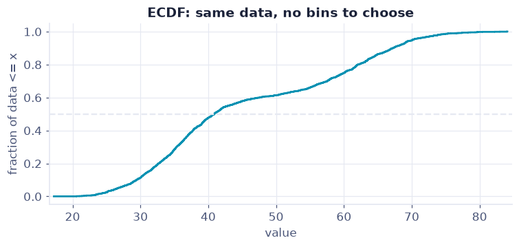

```python
# ECDF: a bin-free alternative to the histogram. Sort the values, plot the running
# fraction <= x. No bin width to bias the picture, and the two rises reveal the two modes.
xs = np.sort(data); ecdf = np.arange(1, len(xs) + 1) / len(xs)
fig, ax = plt.subplots(figsize=(7, 3.4))
ax.step(xs, ecdf, where="post", color=CYAN, lw=1.8)
ax.axhline(0.5, color=GRID, ls="--")
ax.set(title="ECDF: same data, no bins to choose", xlabel="value", ylabel="fraction of data <= x")
ax.margins(x=0.01); plt.tight_layout(); plt.show()
```

**A bin-free alternative: the ECDF.** A histogram's shape depends on the bin width you happen to pick. The **empirical cumulative distribution function** sidesteps that entirely: sort the values and plot the running fraction at or below each x. There is nothing to tune, every point is shown exactly, and you can read any percentile straight off the y-axis (the median is where the curve crosses 0.5). The two steep climbs here, near 35 and 62, are the same two modes the box plot hides, surfaced without a single binning decision.

DEMO 2 · WHAT THE BOX HIDES

📦 Box plots compare, but conceal shape

Box plots are unbeatable for comparing many groups at a glance: median, spread, skew, and outliers in almost no ink. Their blind spot is shape. A box plot cannot show modality, two very different distributions can wear the same box.

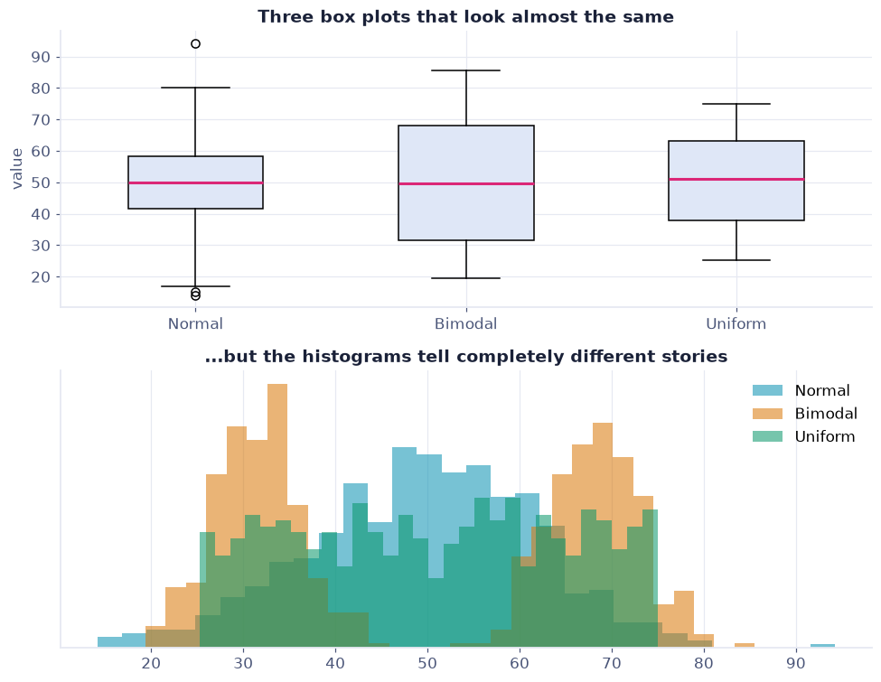

[output not shown]

```python
normal_g  = rng.normal(50, 12, 600)
bimodal_g = np.concatenate([rng.normal(32, 5, 300), rng.normal(68, 5, 300)])  # same rough center/spread
uniform_g = rng.uniform(25, 75, 600)
groups = [normal_g, bimodal_g, uniform_g]; names = ["Normal", "Bimodal", "Uniform"]

fig, (top, bot) = plt.subplots(2, 1, figsize=(9, 7))
bp = top.boxplot(groups, showfliers=True, patch_artist=True, widths=0.5)
for patch in bp["boxes"]: patch.set_facecolor("#dfe7f7")
for med in bp["medians"]: med.set_color(PINK); med.set_linewidth(2)
top.set_xticks([1,2,3]); top.set_xticklabels(names)
top.set_title("Three box plots that look almost the same"); top.set_ylabel("value")

for i, (g, c) in enumerate(zip(groups, [CYAN, AMBER, GREEN])):
    bot.hist(g, bins=30, density=True, alpha=0.55, color=c, label=names[i])
bot.set_title("...but the histograms tell completely different stories")
bot.set_yticks([]); bot.legend()
plt.tight_layout(); plt.show()
for g, n in zip(groups, names):
    q1, med, q3 = np.percentile(g, [25, 50, 75])
    print(f"{n:8} median={med:5.1f}  Q1={q1:5.1f}  Q3={q3:5.1f}  (similar five-number summaries)")
```

DEMO 3 · TAMING SPAGHETTI

📈 The line chart, decluttered

Line charts are for trends over an ordered axis, above all time. Stack too many lines and you get an unreadable tangle. The fix: highlight the one series that carries your message and gray the rest, then label it directly.

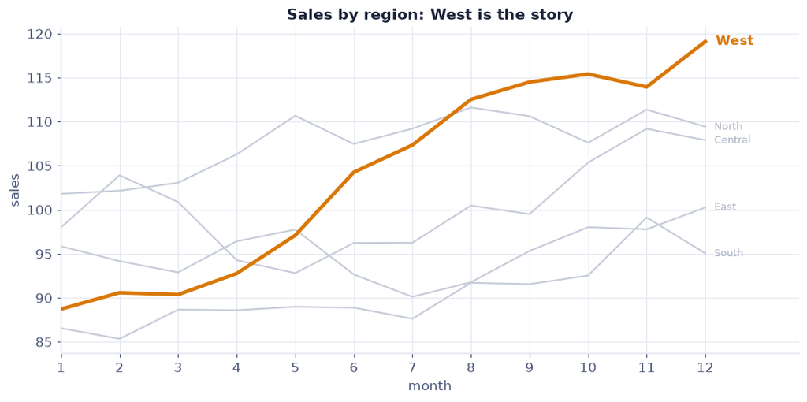

```
One color does the talking. Note: line charts need NOT start at zero (position, not length, encodes value).
```

```python
months = np.arange(1, 13)
regions = {"North": 100, "South": 90, "East": 95, "West": 88, "Central": 92}
series = {r: base + np.cumsum(rng.normal(2 if r=="West" else 0.4, 3, 12)) for r, base in regions.items()}

fig, ax = plt.subplots(figsize=(9.5, 4.8))
for r, y in series.items():
    if r == "West":
        ax.plot(months, y, color=AMBER, lw=3, zorder=5)
        ax.text(months[-1]+0.1, y[-1], " West", color=AMBER, fontweight="bold", va="center")
    else:
        ax.plot(months, y, color="#c7ccda", lw=1.4)
        ax.text(months[-1]+0.1, y[-1], f" {r}", color="#aab0c0", fontsize=8.5, va="center")
ax.set_title("Sales by region: West is the story"); ax.set_xlabel("month"); ax.set_ylabel("sales")
ax.set_xlim(1, 13.6); ax.set_xticks(months)
plt.tight_layout(); plt.show()
print("One color does the talking. Note: line charts need NOT start at zero (position, not length, encodes value).")
```

DEMO 4 · READING A SCATTER

🔍 Relationship between two variables

A scatter plot answers: is there a relationship, and what is its direction, form, and strength? With many points a solid blob hides the density, so reach for transparency or a hexbin. And remember: a tight scatter is association, not proof of cause.

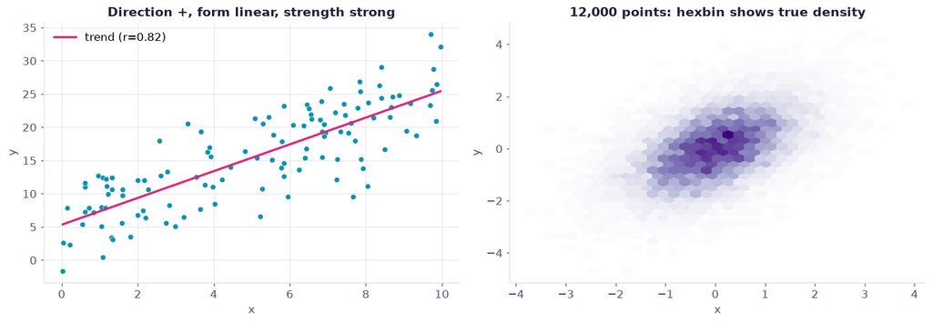

```
trend line: y = 2.02x + 5.33,  r = 0.82. A line summarizes, but always look at the cloud first.
```

```python
# a clear positive relationship with a trend line
x = rng.uniform(0, 10, 120)
y = 2.2 * x + 5 + rng.normal(0, 4, 120)
m, b = np.polyfit(x, y, 1)
r = np.corrcoef(x, y)[0, 1]

# a heavily overplotted cloud
bigx = rng.normal(0, 1, 12000); bigy = bigx * 0.6 + rng.normal(0, 1, 12000)

fig, (a1, a2) = plt.subplots(1, 2, figsize=(13, 4.6))
a1.scatter(x, y, color=CYAN, s=28, edgecolor="white", linewidth=0.4)
a1.plot(np.sort(x), m*np.sort(x)+b, color=PINK, lw=2.2, label=f"trend (r={r:.2f})")
a1.set_title("Direction +, form linear, strength strong"); a1.set_xlabel("x"); a1.set_ylabel("y"); a1.legend()

hb = a2.hexbin(bigx, bigy, gridsize=35, cmap="Purples", mincnt=1)
a2.set_title("12,000 points: hexbin shows true density"); a2.set_xlabel("x"); a2.set_ylabel("y")
a2.grid(False)
plt.tight_layout(); plt.show()
print(f"trend line: y = {m:.2f}x + {b:.2f},  r = {r:.2f}. A line summarizes, but always look at the cloud first.")
```

DEMO 5 · ANSCOMBE'S QUARTET

🧮 Identical stats, four different worlds

Four datasets with the SAME mean, variance, correlation, and regression line. The summary numbers are interchangeable; the scatterplots are nothing alike. This is the canonical argument for always plotting your data before you trust a statistic.

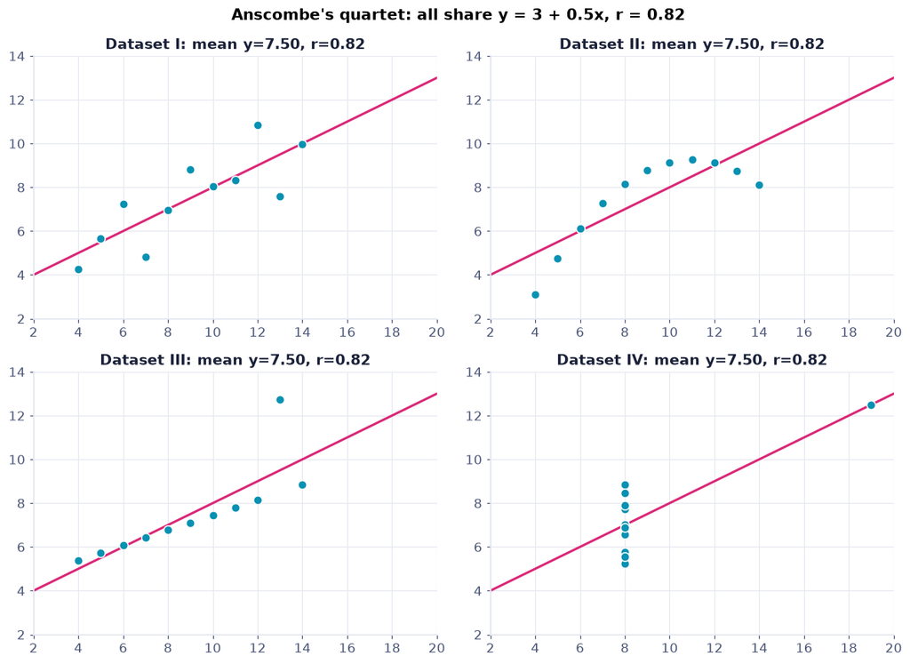

```
Same regression line through all four. Only the picture reveals the curve, the outlier, and the leverage point.
```

```python
x123 = np.array([10,8,13,9,11,14,6,4,12,7,5], float)
x4   = np.array([8,8,8,8,8,8,8,19,8,8,8], float)
Y = {
  "I":   np.array([8.04,6.95,7.58,8.81,8.33,9.96,7.24,4.26,10.84,4.82,5.68]),
  "II":  np.array([9.14,8.14,8.74,8.77,9.26,8.10,6.13,3.10,9.13,7.26,4.74]),
  "III": np.array([7.46,6.77,12.74,7.11,7.81,8.84,6.08,5.39,8.15,6.42,5.73]),
  "IV":  np.array([6.58,5.76,7.71,8.84,8.47,7.04,5.25,12.50,5.56,7.91,6.89]),
}
xs = {"I":x123,"II":x123,"III":x123,"IV":x4}

fig, axes = plt.subplots(2, 2, figsize=(11, 8))
line = np.array([2, 20])
for ax, key in zip(axes.ravel(), ["I","II","III","IV"]):
    xv, yv = xs[key], Y[key]
    ax.scatter(xv, yv, color=CYAN, s=55, edgecolor="white", zorder=5)
    ax.plot(line, 3 + 0.5*line, color=PINK, lw=2)        # the SAME line for all four
    ax.set_title(f"Dataset {key}: mean y={yv.mean():.2f}, r={np.corrcoef(xv,yv)[0,1]:.2f}")
    ax.set_xlim(2,20); ax.set_ylim(2,14)
fig.suptitle("Anscombe's quartet: all share y = 3 + 0.5x, r = 0.82", fontsize=13, fontweight="bold")
plt.tight_layout(); plt.show()
print("Same regression line through all four. Only the picture reveals the curve, the outlier, and the leverage point.")
```

## ✈️ Real-World Example: Flight Arrival Delays

A single numeric variable with real character: 500 arrival delays. The **histogram** shows the shape (most flights near on-time, a long right tail of bad delays), while the **box plot** puts numbers on it, the median, the quartiles, and the cloud of long-delay **outliers** past the upper whisker. Two charts, two complementary reads of the same column.

```
mean 13.5 min   median 8 min   skew 2.60
Q1 1   Q3 17   upper fence 41   long-delay outliers: 46
```

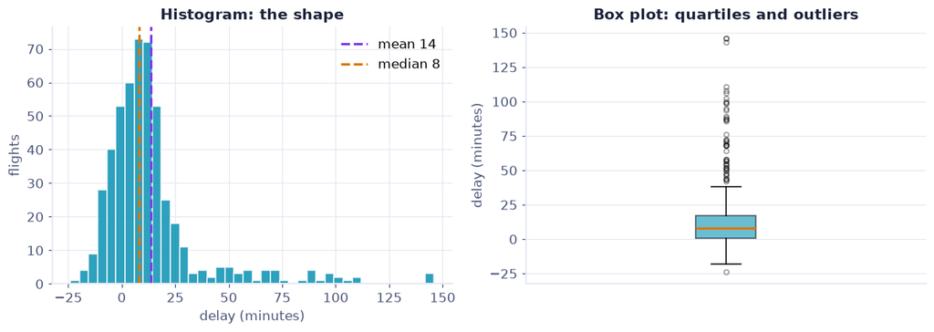

```python
# --- Real-World beat: histogram and box plot of a skewed numeric variable ---
BASE = "https://raw.githubusercontent.com/johnfisher-ai/Statistics-Data-Science-AI-Visual-Book/main/data/"
try:    flights = pd.read_excel("../../data/ch15_flight_delays.xlsx", sheet_name="Data")
except FileNotFoundError: flights = pd.read_excel(BASE+"ch15_flight_delays.xlsx", sheet_name="Data")
d = flights.delay_minutes
q1, q3 = d.quantile([.25, .75]); fence = q3 + 1.5*(q3-q1)
print(f"mean {d.mean():.1f} min   median {d.median():.0f} min   skew {d.skew():.2f}")
print(f"Q1 {q1:.0f}   Q3 {q3:.0f}   upper fence {fence:.0f}   long-delay outliers: {(d > fence).sum()}")
fig, ax = plt.subplots(1, 2, figsize=(11,4))
ax[0].hist(d, bins=40, color=CYAN, alpha=0.85, edgecolor="white")
ax[0].axvline(d.mean(), color=PURPLE, ls="--", lw=2, label=f"mean {d.mean():.0f}")
ax[0].axvline(d.median(), color=AMBER, ls="--", lw=2, label=f"median {d.median():.0f}")
ax[0].set_title("Histogram: the shape"); ax[0].set_xlabel("delay (minutes)"); ax[0].set_ylabel("flights"); ax[0].legend()
ax[1].boxplot(d, patch_artist=True, boxprops=dict(facecolor=CYAN, alpha=0.6),
              medianprops=dict(color=AMBER, linewidth=2), flierprops=dict(marker="o", markersize=4, alpha=0.4))
ax[1].set_title("Box plot: quartiles and outliers"); ax[1].set_ylabel("delay (minutes)"); ax[1].set_xticks([])
plt.tight_layout(); plt.show()
```

🎓 Recap

- The **histogram** shows one variable's shape, but bin width is editorial: try several, lean on Freedman-Diaconis.
- **Box plots** compare groups compactly yet hide modality; a violin or strip plot shows what the box conceals.
- **Line charts** are for ordered/time data; declutter spaghetti by highlighting one series. They need not start at zero.
- **Scatter plots** show direction, form, and strength of a relationship; fight overplotting with alpha or hexbin.
- **Anscombe's quartet**: identical summary stats, four different shapes. Always plot your data.

Statistics, Data Science and AI: A Visual Handbook · © 2026 John Fisher

←Back to the bookChapter 15 · Charts for Numerical Data